# Projet Statistique — Analyse de l’Espérance de Vie (Données OMS)

# 3 Analyse univariée

## 3.1 Statistiques descriptives numériques

```r
# Utilisation de describe() pour obtenir la moyenne, écart-type, etc.
psych::describe(dplyr::select(data, where(is.numeric)))
```

```
##                                 vars    n        mean          sd     median
## Year                               1 2938     2007.52        4.61    2008.00
## Life.expectancy                    2 2938       69.22        9.51      72.00
## Adult.Mortality                    3 2938      164.80      124.08     144.00
## infant.deaths                      4 2938       30.30      117.93       3.00
## Alcohol                            5 2938        4.60        3.92       4.16
## percentage.expenditure             6 2938      738.25     1987.91      64.91
## Hepatitis.B                        7 2938       80.94       22.59      87.00
## Measles                            8 2938     2419.59    11467.27      17.00
## BMI                                9 2938       38.32       19.93      43.00
## under.five.deaths                 10 2938       42.04      160.45       4.00
## Polio                             11 2938       82.55       23.35      93.00
## Total.expenditure                 12 2938        5.94        2.40       5.94
## Diphtheria                        13 2938       82.32       23.64      93.00
## HIV.AIDS                          14 2938        1.74        5.08       0.10
## GDP                               15 2938     7483.16    13136.80    3116.56
## Population                        16 2938 12753375.12 53815462.56 3675929.00
## thinness..1.19.years              17 2938        4.84        4.39       3.40
## thinness.5.9.years                18 2938        4.87        4.48       3.40
## Income.composition.of.resources   19 2938        0.63        0.20       0.66
## Schooling                         20 2938       11.99        3.26      12.10
##                                    trimmed        mad     min           max
## Year                               2007.52       5.93 2000.00       2015.00
## Life.expectancy                      69.91       8.60   36.30         89.00
## Adult.Mortality                     150.54     111.19    1.00        723.00
## infant.deaths                        10.20       4.45    0.00       1800.00
## Alcohol                               4.24       4.67    0.01         17.87
## percentage.expenditure              230.74      96.24    0.00      19479.91
## Hepatitis.B                          86.13      11.86    1.00         99.00
## Measles                             286.08      25.20    0.00     212183.00
## BMI                                  39.04      24.17    1.00         87.30
## under.five.deaths                    14.15       5.93    0.00       2500.00
## Polio                                88.03       8.90    3.00         99.00
## Total.expenditure                     5.85       2.21    0.37         17.60
## Diphtheria                           87.97       8.90    2.00         99.00
## HIV.AIDS                              0.54       0.00    0.10         50.60
## GDP                                4193.58    4196.52    1.68     119172.74
## Population                      6010174.12 5402887.95   34.00 1293859294.00
## thinness..1.19.years                  4.14       3.56    0.10         27.70
## thinness.5.9.years                    4.16       3.56    0.10         28.60
```

[output cut: 8 more lines]

```
## percentage.expenditure               19479.91  4.65    26.51     36.68
## Hepatitis.B                             98.00 -2.14     4.09      0.42
## Measles                             212183.00  9.43   114.58    211.56
## BMI                                     86.30 -0.22    -1.27      0.37
## under.five.deaths                     2500.00  9.49   109.49      2.96
## Polio                                   96.00 -2.10     3.81      0.43
## Total.expenditure                       17.23  0.64     1.49      0.04
## Diphtheria                              97.00 -2.08     3.59      0.44
## HIV.AIDS                                50.50  5.39    34.80      0.09
## GDP                                 119171.06  3.48    15.05    242.36
## Population                      1293859260.00 18.02   382.76 992844.38
## thinness..1.19.years                    27.60  1.72     4.04      0.08
## thinness.5.9.years                      28.50  1.79     4.43      0.08
## Income.composition.of.resources          0.95 -1.18     1.65      0.00
## Schooling                               20.70 -0.62     1.11      0.06
```

Interprétation : on repère les variables avec fortes dispersions ou distribution asymétrique.

## 3.2 Histogrammes détaillés

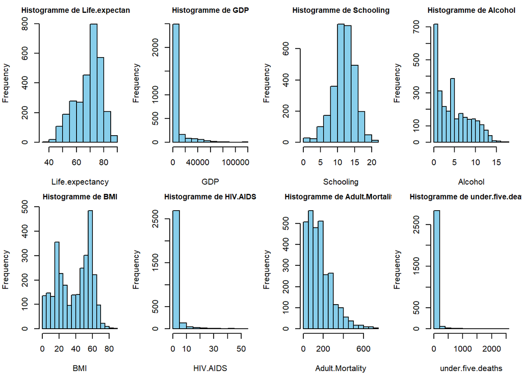

```r
# Choix de variables clés pour explorer leur distribution
vars <- c("Life.expectancy", "GDP", "Schooling", "Alcohol", "BMI", "HIV.AIDS", "Adult.Mortality", "under.five.deaths")
# Disposition en grille 2 x 4
par(mfrow = c(2, 4), mar = c(4, 4, 2, 1))
for (v in vars) {
  hist(data[[v]],
       col = "skyblue",
       main = paste("Histogramme de", v),
       xlab = v,
       cex.main = 0.9)
}
```

```r
par(mfrow = c(1, 1))  # Retour à l'affichage standard
```

Interprétation : - Les histogrammes montrent la forme (normale, biaisée, multimodale). - On note par exemple si l’IMC (BMI) suit une distribution normale ou s’il y a des valeurs extrêmes.

## 3.3 Boxplots par statut

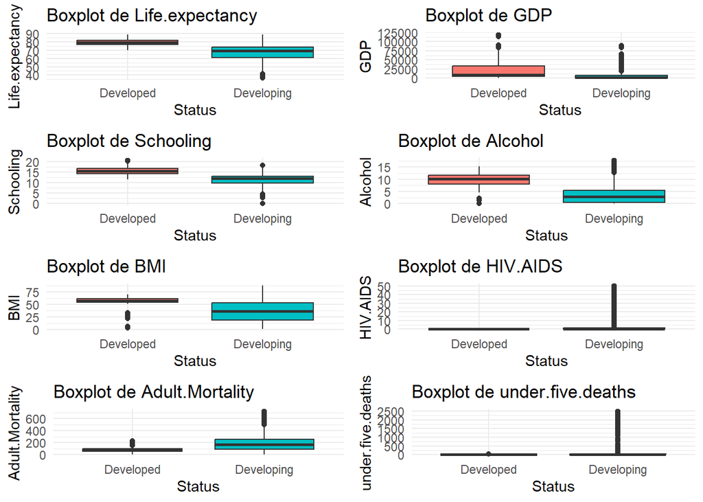

```r
# Création d'une liste de boxplots distinguant pays développés vs en développement
plots_box = lapply(vars, function(v) {
  ggplot(data, aes_string(x = "Status", y = v, fill = "Status")) +
    geom_boxplot() +
    theme_minimal() +
    labs(title = paste("Boxplot de", v), y = v) +
    theme(legend.position = "none")
})
gridExtra::grid.arrange(grobs = plots_box, ncol = 2)
```

Interprétation : - Ces boxplots permettent de comparer la médiane et l’étendue des variables selon le statut. - Par exemple, on s’attend à un PIB (GDP) plus élevé en pays développés.